# U.S. Food Imports

disclaimer: This notebook is contribution to final project of Data Visualization studies.  
Summer Semester 2025, University of Europe for Applied Sciences  
prepared by: **Asa Bejraputra** (70591374)

## 1. Introduction

Source: You could access to the source data [here.](https://www.ers.usda.gov/data-products/us-food-imports)

The U.S. Food Imports data product is an annually published statistical summary of the value and volume of food imports coming into the United States.

U.S. consumers demand variety, quality, and convenience in the foods they consume. As U.S. consumers have become wealthier and more ethnically diverse, their food basket reflects a growing share of tropical products, spices, and imported gourmet products. Seasonal and climatic factors drive U.S. food imports of popular types of fruits, vegetables—and tropical products, such as cocoa and coffee. In addition, a growing share of U.S. imports can be attributed to intra-industry trade, whereby agricultural-processing industries based in the United States carry out certain processing steps offshore and import products at different levels of processing from their subsidiaries in foreign markets.

This data set provides import values of edible products (food and beverages) entering U.S. ports and the products’ origin of shipment. Data are from the U.S. Department of Commerce, Bureau of the Census. Food and beverage import values are compiled by calendar year into food groups, corresponding to major commodities or level of processing. The Harmonized System (HS) codes and the corresponding commodities and food products are detailed in the data product file. At least 20 years of annual data are included, enabling users to track long-term growth patterns.

The dataset is suppoed to be updated in annaul basis. The one we used is observation of data from 1999 to 2024 (25 years) historical data.

## 2. Dataset Import and Preprocessing

```python
import pandas as pd
import numpy as np
import matplotlib.pyplot as plt
import seaborn as sns

import plotly.graph_objects as go
import plotly.express as px
import plotly.io as pio

pio.renderers.default = 'vscode'
```

```python
# import the data into the work area
raw_data = pd.read_csv('FoodImports.csv', encoding='ISO-8859-1')
```

```python
raw_data.head()
```

|  | Commodity | Country | UOM | Category | SubCategory | RowNumber | YearNum | FoodValue |
| --- | --- | --- | --- | --- | --- | --- | --- | --- |
| 0 | Total live animals | CANADA | Million $ | Animals | Foods | 1 | 1999 | 876.9 |
| 1 | Total live animals | MEXICO | Million $ | Animals | Foods | 2 | 1999 | 292.2 |
| 2 | Total live animals | REST OF WORLD | Million $ | Animals | Foods | 3 | 1999 | 0.1 |
| 3 | Total live animals | WORLD | Million $ | Animals | Foods | 4 | 1999 | 1169.2 |
| 4 | Total live animals | WORLD (Quantity) | 1,000 | Animals | Foods | 5 | 1999 | 6058.4 |

```python
raw_data.drop('RowNumber', axis=1, inplace=True)
```

```python
raw_data.shape
```

```
(19838, 7)
```

Then we preprocess the data into 4 sets to answer 10 questions below

1. Import Value `('data')`: This dataset shows the Import Amount (Quantity * Price) from each Country in each Year from 1999 - 2024
2. Import Quantity `('qtydata')`: This dataset shows the Import Quantity becuase we need to know how much we import the food without price inflation involved.
3. Import Price `('pricedata')`: This dataset shows the Import Price per metric tons of imported commodities.
4. Correlation of Price Inflation `('corr_inflation')`: We use this dataset to find out how the fluctuation of one kind of commodity affects the others through observed period.

```python
# preprocess the Import Value

# filter using only SubCategory == 'Foods'
data = raw_data[raw_data['SubCategory'] == 'Foods']

# fiter out the rows from Commodity column which contains the word 'total'
data = data[~data['Commodity'].str.contains('Total')]

# filter the data['UOM'] == 'Million $' only
data = data[data['UOM'] == 'Million $']

# filter the data['Country'] == 'WORLD' out from the selection
data = data[data['Country'] != 'WORLD']

# typecaseting the data['YearNum] column from string to numeric
data['YearNum'] = data['YearNum'].apply(pd.to_numeric)

# reset the index and drop the orignal index row
data.reset_index(inplace=True,drop=True)

data.head()
```

|  | Commodity | Country | UOM | Category | SubCategory | YearNum | FoodValue |
| --- | --- | --- | --- | --- | --- | --- | --- |
| 0 | Bovine animals, live | CANADA | Million $ | Animals | Foods | 1999 | 639.0 |
| 1 | Bovine animals, live | MEXICO | Million $ | Animals | Foods | 1999 | 292.1 |
| 2 | Swine, live | CANADA | Million $ | Animals | Foods | 1999 | 216.1 |
| 3 | Sheep and goats, live | CANADA | Million $ | Animals | Foods | 1999 | 5.3 |
| 4 | Live poultry | CANADA | Million $ | Animals | Foods | 1999 | 16.5 |

```python
# preprocess the Import Quantity
qtydata = raw_data[(raw_data['Category'] == 'Food volume') & ((raw_data['UOM'] == '1,000 mt') | (raw_data['UOM'] == '1,000 litpf'))]
qtydata['YearNum'] = qtydata['YearNum'].apply(pd.to_numeric)
qtydata.head()
```

|  | Commodity | Country | UOM | Category | SubCategory | YearNum | FoodValue |
| --- | --- | --- | --- | --- | --- | --- | --- |
| 692 | Meats | WORLD (Quantity) | 1,000 mt | Food volume | Foods | 1999 | 1439.6 |
| 693 | Fish and shellfish | WORLD (Quantity) | 1,000 mt | Food volume | Foods | 1999 | 1677.8 |
| 694 | Dairy | WORLD (Quantity) | 1,000 mt | Food volume | Foods | 1999 | 298.8 |
| 695 | Vegetables | WORLD (Quantity) | 1,000 mt | Food volume | Foods | 1999 | 4781.1 |
| 696 | Fruits | WORLD (Quantity) | 1,000 mt | Food volume | Foods | 1999 | 7835.3 |

```python
# preprocess the Import Price
pricedata = raw_data[(raw_data['SubCategory'] == 'Imported food prices') & (raw_data['UOM'] != 'Dollars')].reset_index(drop=True)
pricedata['YearNum'] = pricedata['YearNum'].apply(pd.to_numeric)
pricedata.head()
```

|  | Commodity | Country | UOM | Category | SubCategory | YearNum | FoodValue |
| --- | --- | --- | --- | --- | --- | --- | --- |
| 0 | Meats | WORLD | Dollars per mt | Prices | Imported food prices | 1999 | 2264.865240 |
| 1 | Fish and shellfish | WORLD | Dollars per mt | Prices | Imported food prices | 1999 | 5280.605555 |
| 2 | Dairy | WORLD | Dollars per mt | Prices | Imported food prices | 1999 | 3113.453815 |
| 3 | Vegetables | WORLD | Dollars per mt | Prices | Imported food prices | 1999 | 758.737529 |
| 4 | Fruits | WORLD | Dollars per mt | Prices | Imported food prices | 1999 | 611.808099 |

```python
# Preprocess the Correlation of Price Inflation
inflation_data = raw_data[(raw_data['SubCategory'] == 'Import price inflation') & (raw_data['YearNum'] != 'means')].reset_index(drop=True)
inflation_data['YearNum'] = inflation_data['YearNum'].apply(pd.to_numeric)

inflation_table = pd.pivot_table(inflation_data,values='FoodValue', index=['YearNum'], columns=['Commodity'])
corr_inflation = inflation_table.corr('pearson')
corr_inflation
```

| Commodity | Beverages | Cocoa and chocolate | Coffee, tea, and spices | Dairy | Fish and shellfish | Fruits | Grains | Live meat animals | Meats | Nuts | Sugar and candy | Vegetable oils | Vegetables |
| --- | --- | --- | --- | --- | --- | --- | --- | --- | --- | --- | --- | --- | --- |
| Beverages | 1.000000 | -0.098869 | 0.420839 | 0.459526 | 0.511025 | 0.544319 | 0.195859 | 0.229027 | 0.364178 | 0.392619 | 0.118618 | 0.398076 | -0.176198 |
| Cocoa and chocolate | -0.098869 | 1.000000 | 0.172455 | 0.224776 | -0.191908 | 0.258648 | 0.494747 | 0.025264 | -0.015254 | 0.122201 | 0.053098 | 0.275436 | 0.190221 |
| Coffee, tea, and spices | 0.420839 | 0.172455 | 1.000000 | 0.448696 | 0.470170 | 0.705417 | 0.551208 | 0.035203 | 0.474770 | 0.644477 | 0.284304 | 0.728483 | 0.261929 |
| Dairy | 0.459526 | 0.224776 | 0.448696 | 1.000000 | 0.522490 | 0.432080 | 0.422305 | -0.066422 | 0.663697 | 0.520838 | 0.155781 | 0.559657 | 0.323556 |
| Fish and shellfish | 0.511025 | -0.191908 | 0.470170 | 0.522490 | 1.000000 | 0.503505 | 0.262543 | 0.191116 | 0.608509 | 0.339515 | 0.246126 | 0.371248 | -0.068890 |
| Fruits | 0.544319 | 0.258648 | 0.705417 | 0.432080 | 0.503505 | 1.000000 | 0.506014 | 0.139236 | 0.343925 | 0.449725 | 0.153541 | 0.610923 | 0.131464 |
| Grains | 0.195859 | 0.494747 | 0.551208 | 0.422305 | 0.262543 | 0.506014 | 1.000000 | -0.269196 | 0.366255 | 0.439591 | 0.204095 | 0.704141 | 0.135701 |
| Live meat animals | 0.229027 | 0.025264 | 0.035203 | -0.066422 | 0.191116 | 0.139236 | -0.269196 | 1.000000 | 0.056980 | -0.286674 | -0.198844 | -0.457928 | -0.100064 |
| Meats | 0.364178 | -0.015254 | 0.474770 | 0.663697 | 0.608509 | 0.343925 | 0.366255 | 0.056980 | 1.000000 | 0.527066 | 0.183710 | 0.467323 | 0.260854 |
| Nuts | 0.392619 | 0.122201 | 0.644477 | 0.520838 | 0.339515 | 0.449725 | 0.439591 | -0.286674 | 0.527066 | 1.000000 | -0.089077 | 0.627146 | 0.285220 |
| Sugar and candy | 0.118618 | 0.053098 | 0.284304 | 0.155781 | 0.246126 | 0.153541 | 0.204095 | -0.198844 | 0.183710 | -0.089077 | 1.000000 | 0.348427 | -0.271348 |
| Vegetable oils | 0.398076 | 0.275436 | 0.728483 | 0.559657 | 0.371248 | 0.610923 | 0.704141 | -0.457928 | 0.467323 | 0.627146 | 0.348427 | 1.000000 | 0.244788 |
| Vegetables | -0.176198 | 0.190221 | 0.261929 | 0.323556 | -0.068890 | 0.131464 | 0.135701 | -0.100064 | 0.260854 | 0.285220 | -0.271348 | 0.244788 | 1.000000 |

**Dataset Questions**

1. What are the 5 largest Category of U.S. food imports by amount in the last 25 years, and their Commodities?
2. Who are the US's biggest food exporters?
3. What kind of commodities which US imported the most from Canada in the last 5 years?
4. How's the change of trend of food imports from each category by their value over time?
5. Who is the biggest exporters of US's beverages, and what kind of beverages that US imported from them?
6. Who is the biggest exporters of US's fruits, and what kind of fruits that US imported from them?
7. Who is the biggest exporters of US's fishes, and what kind of fishes that US imported from them?
8. How is the import demand of the product shift over last 25 years?
9. How is the price of each Food Category fluctuates for the last 25 years?
10. How is the price of each kind of commodities correlates with each other for the last 25 years?

## 3. Analysis And Visualization

### Q1: What are the 5 largest Category of U.S. food imports by amount in the last 25 years, and their Commodities?

```python
fig = px.bar(data.groupby(['Category','Commodity'])[['FoodValue']].sum().sort_values(by='FoodValue',ascending=False).reset_index(),
             x='Category', y='FoodValue', color='Commodity')

fig.update_layout(title='Total US Food Import by Category (1999 - 2024)',
                  yaxis={
                      'title':{
                          'text': 'Total Import Amount (Million $)'
                        }
                    }
                )
fig.show()
```

[output not shown]

For the last 25 years, we could see that US spend their money for importing the **Beverages** the most. Then followed by **Fish** and **Fruits** respectively.

### Q2: Who are the US's biggest food exporters?

```python
value_by_country = data.groupby('Country')['FoodValue'].sum().sort_values(ascending=False)

fig = px.choropleth(data_frame=value_by_country.to_frame(),
                    locations=value_by_country.index, locationmode='country names',
                    color=value_by_country.values,
                    color_continuous_scale=px.colors.sequential.YlOrRd,
                    labels={'color': 'Import Value (Million $)'},
                    title='Total US Food Import Amount by Country 1999 - 2024')

fig.show()
```

[output not shown]

Obviously, there're numbers of trade partner which US imports the foods from. However, around two-third of their foods imports was made with their close neighbors e.g. **Canada** and **Mexico**.

### Q3: What kind of commodities which US imported the most from Canada in the last 5 years?

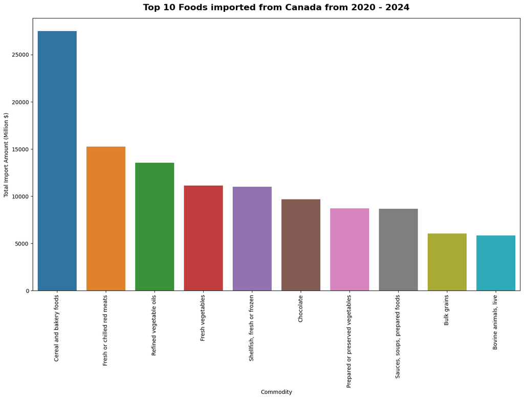

```python
data_ca_5yr = data[(data['Country'] == 'CANADA') & (data['YearNum'] >= 2020)]
data_ca_5yr = data_ca_5yr.groupby('Commodity')['FoodValue'].sum().sort_values(ascending=False).to_frame()

fig, ax = plt.subplots(figsize=(16,9))
sns.barplot(data_ca_5yr[:10],
            x='Commodity', y='FoodValue',
            errorbar=None, legend=None,
            hue='Commodity')

ax.set_xticklabels(data_ca_5yr.index[:10].to_list(), rotation = 90)
ax.set_ylabel('Total Import Amount (Million $)')
ax.set_title('Top 10 Foods imported from Canada from 2020 - 2024',
             fontweight='bold', fontsize=16, pad=15)
```

Then, speaking of Canada, the U.S. is a major importer of their **Cereal**, **Bakery**, and **Red Meats**.

### Q4: How's the change of trend of food imports from each category by their value over time?

```python
fig = px.line(data.groupby(['YearNum','Category'])[['FoodValue']].sum().reset_index(),
              x='YearNum', y='FoodValue', color='Category', symbol='Category')

fig.update_layout(title='US Food Import by Amount per Category (1999 - 2024)',
                  yaxis={
                      'title':{
                          'text': 'Total Import Amount (Million $)'
                        }
                    },
                  xaxis={
                      'title':{
                          'text': 'Year'
                        }
                    }
                )

fig.show()
```

[output not shown]

When we take a look on the changes in Import Value for the last 25 years. We could see that **Beverages** is the main items which U.S. import from the outside until the last 2 years which the top position goes to **Fruits**.

### Q5: Who is the biggest exporters of US's beverages, and what kind of beverages that US imported from them?

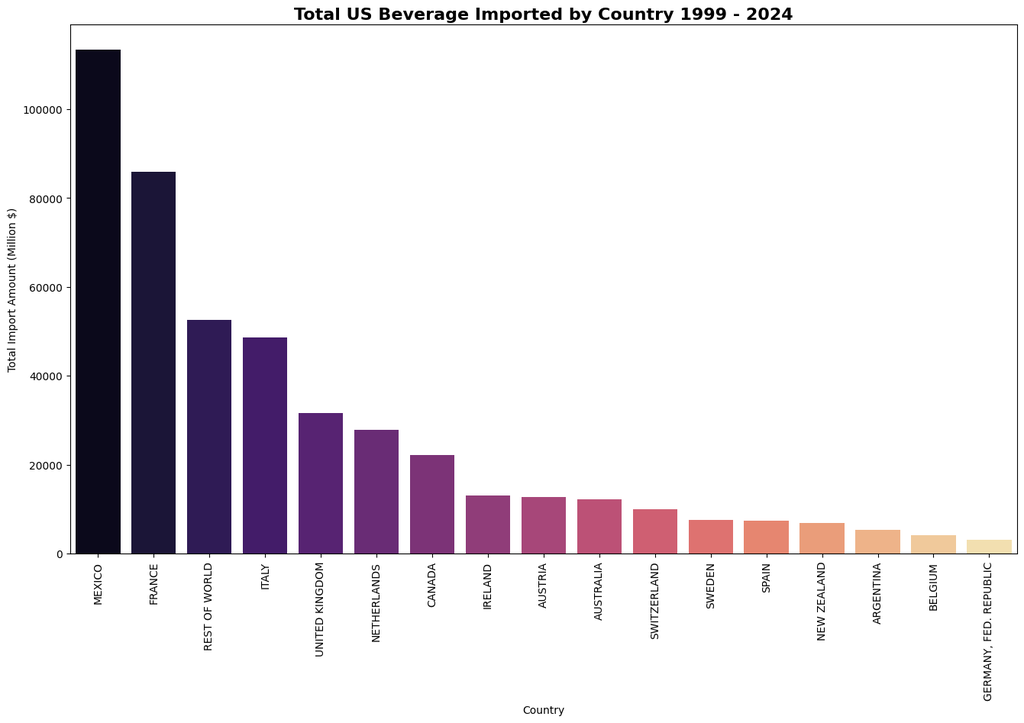

```python
data_bev = data[data['Category'] == "Beverages"]
data_bev = data_bev.groupby(['Country'])['FoodValue'].sum().sort_values(ascending=False).to_frame().reset_index()

fig, ax = plt.subplots(figsize=(16,9))
sns.barplot(data_bev, x='Country', y='FoodValue', hue='Country',palette='magma',errorbar=None)
ax.set_xticklabels(data_bev['Country'].to_list(), rotation=90)
ax.set_ylabel('Total Import Amount (Million $)')
ax.set_title('Total US Beverage Imported by Country 1999 - 2024',
             fontweight='bold', fontsize=16, pad=5)

fig.show()
```

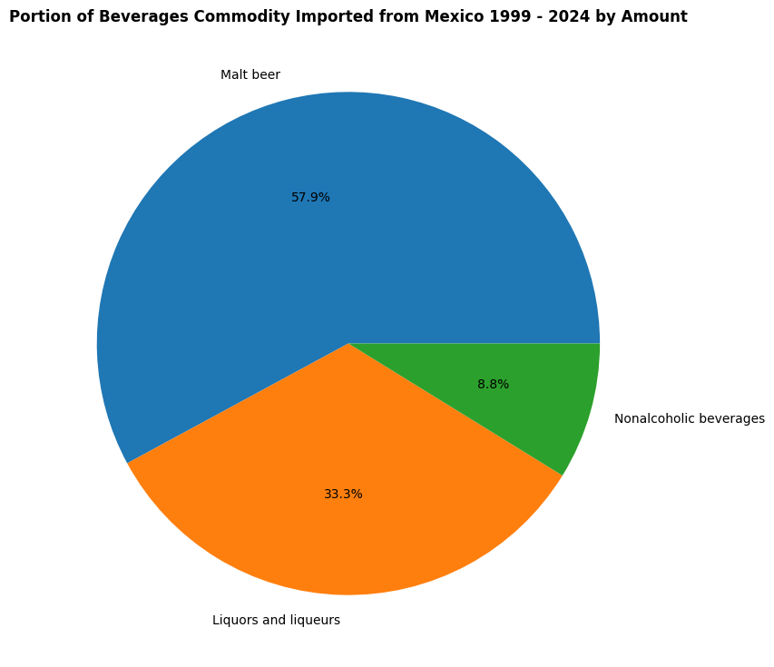

```python
data_bev_mex = data[(data['Category'] == "Beverages") & (data['Country'] == "MEXICO")]
data_bev_mex = data_bev_mex.groupby(['Commodity'])['FoodValue'].sum().sort_values(ascending=False)
fig, ax = plt.subplots(figsize=(16,9))
ax.pie(
    data_bev_mex,
    labels = data_bev_mex.index,
    autopct='%1.1f%%'
)

ax.set_title('Portion of Beverages Commodity Imported from Mexico 1999 - 2024 by Amount',
             fontweight='bold')

fig.show()
```

After we found that the main Food which U.S. import are **Beverages**, **Fruits**, and **Fishes**, then we will take a look into detail that who are their biggest trade partner, and which kind of Commodities that U.S. imported from them

When we take a look into Beverages imports for the last 25 years, we found that **Mexico** is U.S. main exporters. The U.S. mostly bought **Malt Beer**, **Liqour**, and **Non-Alcoholoc Beverages** from them.

### Q6: Who is the biggest exporters of US's fruits, and what kind of fruits that US imported from them?

[figure not shown]

```python
data_fruits = data[data['Category'] == "Fruits"]
data_fruits = data_fruits.groupby(['Country'])['FoodValue'].sum().sort_values(ascending=False).to_frame().reset_index()

fig, ax = plt.subplots(figsize=(16,9))
sns.barplot(data_fruits, x='Country', y='FoodValue', hue='Country',palette='viridis',errorbar=None)
ax.set_xticklabels(data_bev['Country'].to_list(), rotation=90)
ax.set_ylabel('Total Import Amount (Million $)')
ax.set_title('Total US Fruits Imported by Country 1999 - 2024',
             fontweight='bold', fontsize=16, pad=5)

fig.show()
```

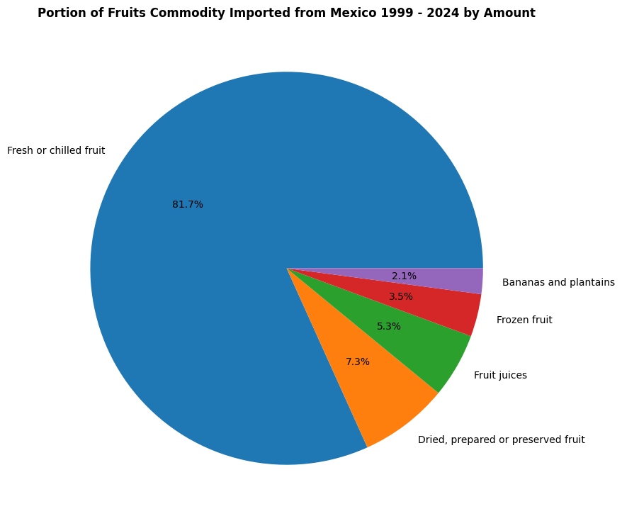

```python
data_fruits_mex = data[(data['Category'] == "Fruits") & (data['Country'] == "MEXICO")]
data_fruits_mex = data_fruits_mex.groupby(['Commodity'])['FoodValue'].sum().sort_values(ascending=False)
fig, ax = plt.subplots(figsize=(16,9))
ax.pie(
    data_fruits_mex,
    labels = data_fruits_mex.index,
    autopct='%1.1f%%'
)

ax.set_title('Portion of Fruits Commodity Imported from Mexico 1999 - 2024 by Amount',
             fontweight='bold')

fig.show()
```

In terms of imported fruits, **Mexico** is still their biggest trade partner in Fruits. Most of them are **Fresh and Chilled Fruit**, which their values is more than other kind of fruits combined.

### Q7: Who is the biggest exporters of US's fishes, and what kind of fishes that US imported from them?

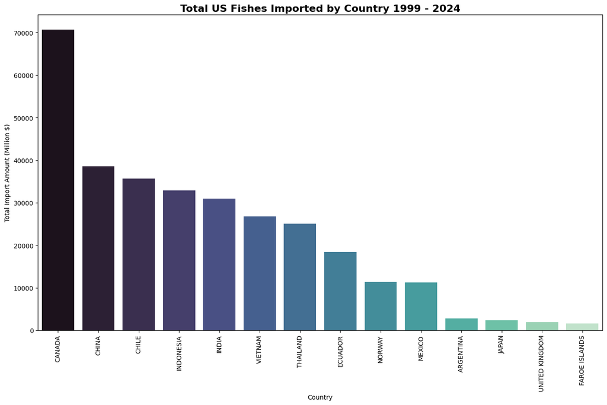

```python
data_fishes = data[data['Category'] == "Fish"]
data_fishes = data_fishes.groupby(['Country'])['FoodValue'].sum().sort_values(ascending=False).to_frame()[1:].reset_index()

fig, ax = plt.subplots(figsize=(16,9))
sns.barplot(data_fishes, x='Country', y='FoodValue', hue='Country',palette='mako',errorbar=None)
ax.set_xticklabels(data_fishes['Country'].to_list(), rotation=90)
ax.set_ylabel('Total Import Amount (Million $)')
ax.set_title('Total US Fishes Imported by Country 1999 - 2024',
             fontweight='bold', fontsize=16, pad=5)

fig.show()
```

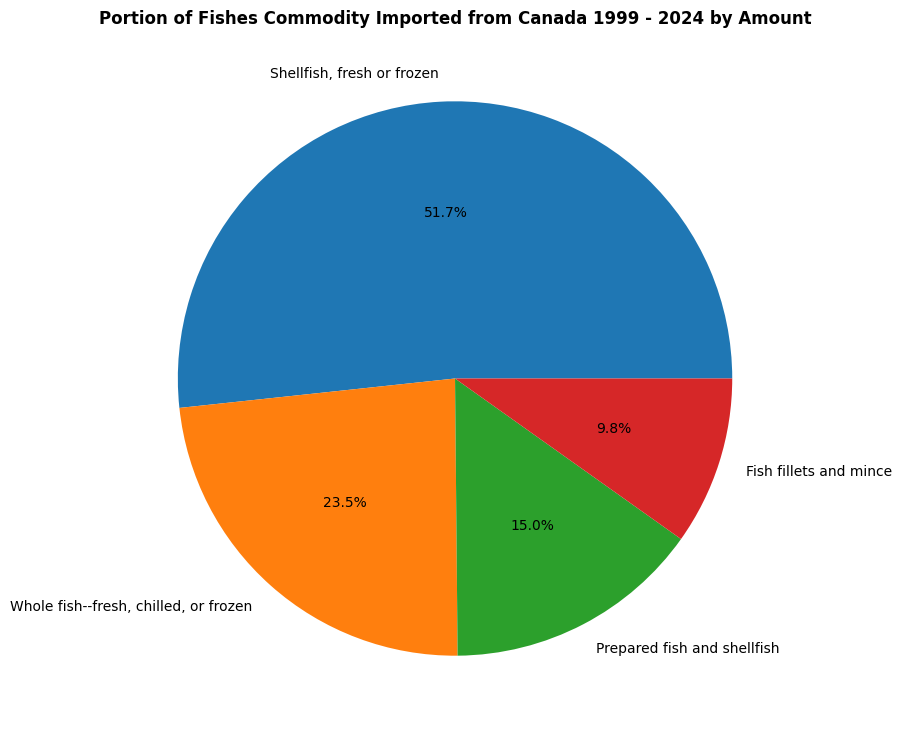

```python
data_fishes_ca = data[(data['Category'] == "Fish") & (data['Country'] == "CANADA")]
data_fishes_ca = data_fishes_ca.groupby(['Commodity'])['FoodValue'].sum().sort_values(ascending=False)

fig, ax = plt.subplots(figsize=(16,9))
ax.pie(
    data_fishes_ca,
    labels = data_fishes_ca.index,
    autopct='%1.1f%%'
)

ax.set_title('Portion of Fishes Commodity Imported from Canada 1999 - 2024 by Amount',
             fontweight='bold')

fig.show()
```

In terms of Fishes import, **Canada** is their main exporters here. Majority of their exports are **Fresh or Frozen Shellfish**.

### Q8: How is the import demand of the product shift over last 25 years?

```python
fig = px.line(qtydata,
              x='YearNum', y='FoodValue', color='Commodity', symbol='Commodity')

fig.update_layout(title='US Food Import Demand by Qty (1999 - 2024)',
                  yaxis={
                      'title':{
                          'text': 'Import Qty (Metric Tons)'
                        }
                    },
                  xaxis={
                      'title':{
                          'text': 'Year'
                        }
                    }
                )

fig.show()
```

[output not shown]

Then, we take a look of the Import Quantity for the last 25 years, we found that there're only some kind of Foods which the import quantity grows e.g. **Fruits, Vegetables, Grains, Beverages, and Vegetable Oils**, while demands of other kind of foods is grow a bit slower.

### Q9: How is the price of each Food Category fluctuates for the last 25 years?

```python
fig = px.line(pricedata,
              x='YearNum', y='FoodValue', color='Commodity', symbol='Commodity')

fig.update_layout(title='US Food Import Price (1999 - 2024)',
                  yaxis={
                      'title':{
                          'text': 'Price ($ per Metric Tons)'
                        }
                    },
                  xaxis={
                      'title':{
                          'text': 'Year'
                        }
                    }
                )

fig.show()
```

[output not shown]

In terms of Price, we found that price of fishes is noticeably more expensive than the other kind of imported foods. Moreover their rate of price inflation is noticeably faster than everyones here. This could explain that why Import Value of Fishes is getting higher for the last 25 years while their demand doesn't change that much.

### Q10: How is the price of each kind of commodities correlates with each other for the last 25 years?

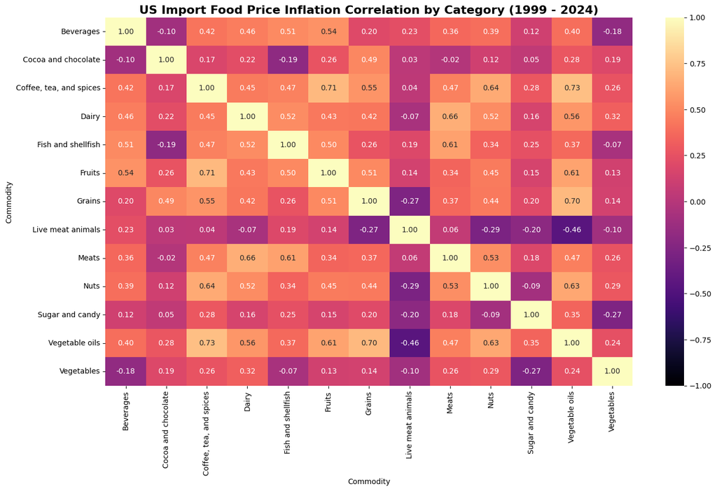

```python
fig, ax = plt.subplots(figsize=(16,9))
sns.heatmap(corr_inflation,
            cmap='magma',
            fmt='.2f',
            annot=True,
            vmin=-1, vmax=1)

ax.set_title('US Import Food Price Inflation Correlation by Category (1999 - 2024)',
             fontweight='bold', fontsize=16, pad=5)

fig.show()
```

Then, we compared the price inflation over the years of each kind of Foods compared to each other. For example, we could see the patterns with strong correlation as follows:

- Fruits' price are positively correlated with Coffe, Tea, and Spices.
- Meats' price are positively correlated with Dairy, and Fishes.
- Nuts' price are positively correlated with Coffe, Tea, and Spices.
- Vegetable Oils are positively correlated with Coffee, Tea, Spices, and Grains.

But most of them are positively correlated betweeen each other.